# EuroCrim 2019, poster session. Supplemental file.

Alberto Chrysoulakis, Malmö university; e-mail: alberto.chrysoulakis@mau.se

2019-09-19

## “Testing the Situational Action Theory’s perception-choice process using randomized scenarios”

This is an R Markdown document where you can find complementary, and more detailed, information regarding the work behind my poster.

The “Background” is already there: to test the Situational Action Theory’s (SAT) *perception-choice process*. Prior work by for instance Wikström as well as Pauwels has found some support for an interaction effect between individual level of crime propensity and setting criminogeneity (also tested using fictive scenarios/vignettes). However, the work has mainly been on projected use of violence. This study also tests the projected use of theft, and it tests two time points within the same sample.

### Method

The study focuses on three aspects: (i) the individuals level of crime propensity [predictor], (ii) an individuals projected likelihood of theft and violence [the outcome], contingent upon (iii) a varying level of motivation (temptation for theft, friction for violence) and deterrence [consistent of four different scenarios].

I will briefly explain and describe these three before showing the main analyses on which the density plots are based upon.

#### Crime propensity

Following the prior work of Wikström, **crime propensity** consists of two subscales: *personal morality* (16 items) and *the ability to exercise self control* (8 items). These have been estimated separately using confirmatory factory analysis in Mplus. The factor scores for each individual on each scale has been saved and subsequently added. Hence, **crime propensity** has been calculated as (Factorscores_morality + factorscores_self-control)/2.

The model fit indices for all CFA models are presented below.

| Model | Chi<sup>2</sup> (df), p-value | CFI/TLI | RMSEA |
| --- | --- | --- | --- |
| Morality, time 1 | 288.913(85), .000 | .963/.954 | .068(.060-.077) |
| Morality, time 2 | 360.561(85), .000 | .940/.926 | .079(.071-.088) |
| Self-control, time 1 | 33.542(17), .0096 | .99/.98 | .044(.021-.065) |
| Self-conrtol, time 2 | 34.945(17),.006 | .989/.982 | .045(.023-.067) |

#### Projected likelihood of theft/violence

The longitudinal project *Malmö Individual Neighbourhood and Development Study* (MINDS), on which the study is built, has randomized vignettes at two occasions. One vignette regards projected theft, and the other projected use of violence. That is, “projected” in the sense “behavioural intention”.

##### Theft, time 1

Respondents could get one of four scenarios for theft [with randomized components in squared brackets]. Male respondents had a male name in their questionnaire, female respondents had a female name in theirs:

"Peter/Anna is on his/her way to an ATM-machine to withdraw money. When he/she arrives at the ATM, he/she sees that the person before him/her has forgotten [100 SEK (≈10 €) **//** 2000 SEK (≈200 €)] in the machine. Peter/Anna looks around, [but the person has already left and there is no one else who sees what he/she does **//** and a police officer standing behind him/her in the queue to the ATM points towards a person walking away, saying that it was he/she who forgot the money].

“If you were Peter/Anna, how likely is it that you would have taken the [100 SEK // 2000 SEK] and kept it for yourself?”

The answer alternatives, “Very unlikely”, “Unlikely”, “Likely”, “Very likely”, have been collapsed into 0 = (very) Unlikely and 1 = (Very) Likely.

##### Theft, time 2

At time 2, the scenarios also differed in level of motivation/temptation and level of monitoring, but scenarios were not identical nor was the following question on the likelihood of projected theft. The following two scenarios did not include monitoring [with randomized components in squared brackets]:

“David/Felicia has been to the cinema. He/she is the last one to leave the cinema. He/she sees that someone has left [100 SEK (≈ 10 €) // 1000 SEK (≈ 100 €)] on the ground. He/she picks it up and puts it in his/her pocket. No one sees that he/she put the money in his/her pocket. Outside the cinema, a stranger asks him/her if he/she has seen the [100 SEK // 1000 SEK] that the stranger had lost inside the cinema.”

Versus the scenarios including monitoring:

“David/Felicia has been to the cinema. He/she sees that someone has left [100 SEK (≈ 10 €) // 1000 SEK (≈ 100 €)] on the ground. He/she picks it up and puts it in his/her pocket. When he/she has put the money in his/her pocket, he/she notice that a security guard is watching his/her. Outside the cinema, a stranger asks him/her if he/she has seen the [100 SEK // 1000 SEK] that the stranger had lost inside the cinema.”

“If you were David/Felicia, how likely is that you would tell the stranger that you found his/her money and return it to him/her?”

The answer alternatives, “Very likely”, “Likely”, “Unlikely”, “Very unlikely”, have been collapsed into 0 = (very) Likely and 1 = (Very) Unlikely.

##### Violence, time 1

“It is Friday evening. Thomas [male version]/Lisa [female version] is standing in line outside a cinema when another guy/girl cuts in line. Thomas/Lisa asks the guy/girl to get back to his/her place in the queue, but the guy/girl just [ignores // laughs an tell Thomas/Lisa to go to hell]. [There are no adults present, only other peers // Two security guards are standing beside the queue monitoring what is happening].”

“If you were Thomas/Lisa, how likely is it that you would have hit or assaulted the guy/girl cutting in line?”

Answers were also collapsed to 0 = (Very) unlikely, 1 = (Very) likely.

##### Violence, time 2

As for the scenarios involving theft, scenarios on violence are not identical. First, the scenarios with a lower degree of provocation and varying monitoring:

"Louise/Sebastian is waiting for the bus at a bus stop. She/he is listening to her/his iPod. Suddenly a girl/guy passes by and pushes her/him. When Louise/Sebastian asks why the girl/guy pushed her, the girl just ignores her. [There are no other people at the bus stop. // There are two police officers walking on the other side of the street.]

Versus scenarios with a higher degree of provocation:

“Louise/Sebastian is waiting for the bus at a bus stop. She/he is listening to her/his iPod. Suddenly a girl who is walking by pushes her so she drops her iPod to the ground. The iPod breaks. When Louise asks her why she pushed her the girl pushes her again. [There are no other people at the bus stop. // There are two police officers walking on the other side of the street.]”

“If you were Louise/Sebastian, how likely do you think it is that you would hit or push the girl that pushed you?”

As before: 0 = (Very) unlikely, 1 = (Very) likely.

#### Distribution across scenarios?

The table below presents how respondents are distributed across scenarios. Valid percentage. Respondents are more evenly distributed at time 1 than time 2.

| Scenario | 1: | 2: | 3: | 4: |
| --- | --- | --- | --- | --- |
| Time 1 (n=504) | 25.8 | 25.0 | 24.8 | 24.4 |
| Time 2 (n=516) | 28.3 | 22.9 | 28.5 | 20.3 |

#### How is crime propensity distributed across scenarios?

Below is a mean difference test in order to rule out that a skewed distribution of crime propensity might bias the results. First for time 1, and further below for time 2. The results for both time points indicate no significant difference in mean crime propensity across scenarios.

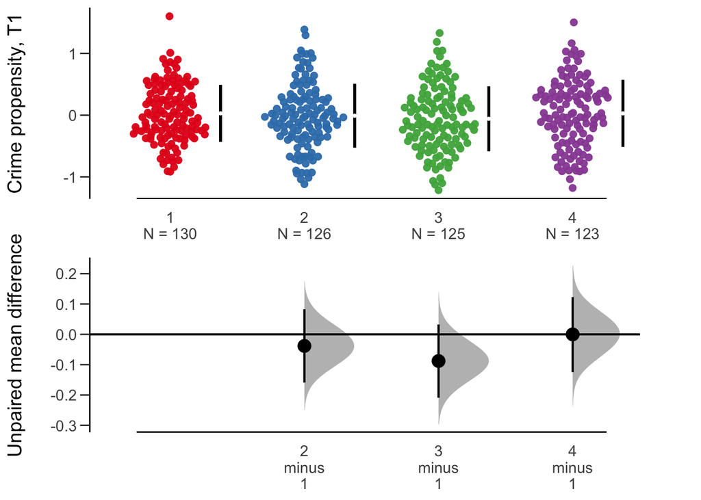

```r
#Using the package "dabestr"
#Crime propensity at time 1 for each scenario.
unpaired_mean_diff1 <- dabest(T1v, Bscen, cp1,
                             idx = c("1", "2", "3", "4"),
                             paired = FALSE
                             )
plot(unpaired_mean_diff1,
     rawplot.ylabel = "Crime propensity, T1"
     )
```

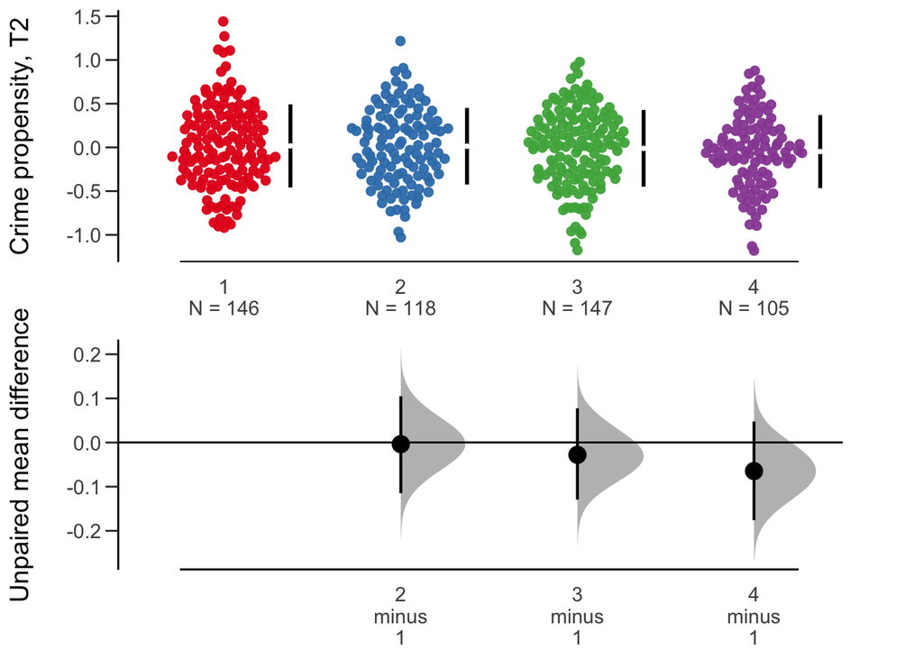

```r
#Crime propensity at time 2 for each scenario.
library(dabestr)
unpaired_mean_diff2 <- dabest(T2v, Cscen, cp2,
                             idx = c("1", "2", "3", "4"),
                             paired = FALSE
                             )
plot(unpaired_mean_diff2,
     rawplot.ylabel = "Crime propensity, T2"
     )
```

### Main analysis

Starting out with a prior predictive simulation illustrating why wide priors are not all that good.

```r
set.seed(123)

m1 <- ulam(
  alist(
    B83bc_dik ~ dbinom(1, p),
    logit(p) <- a[Bscen] + b[Bscen]*cp1,
    a[Bscen] ~ dnorm(0,2) ,              # These intercepts are wide in regards to the probability in the data.
    b[Bscen] ~ dnorm (0,2)
    ),
  data = T1v , chains=4, cores = 2, sample = TRUE, log_lik = TRUE)
```

Extracting priors and converting parameters to the outcome scale with the use of the inverse-link function. The dens plot below illustrates two peaks at 0 and 1, indicating the model expects, before seeing the data, that most individuals are either mostly unlikely (0) or likely (1) of intending theft. A narrower prior used further down (0, 1.5) indicates instead that a the probability is more evenly spread out and as such seen as a more “weak” prior.

```r
pa.m1 <- inv_logit(prior.m1$a)  #Intercept
pb.m1 <- inv_logit(prior.m1$b) #Slope
```

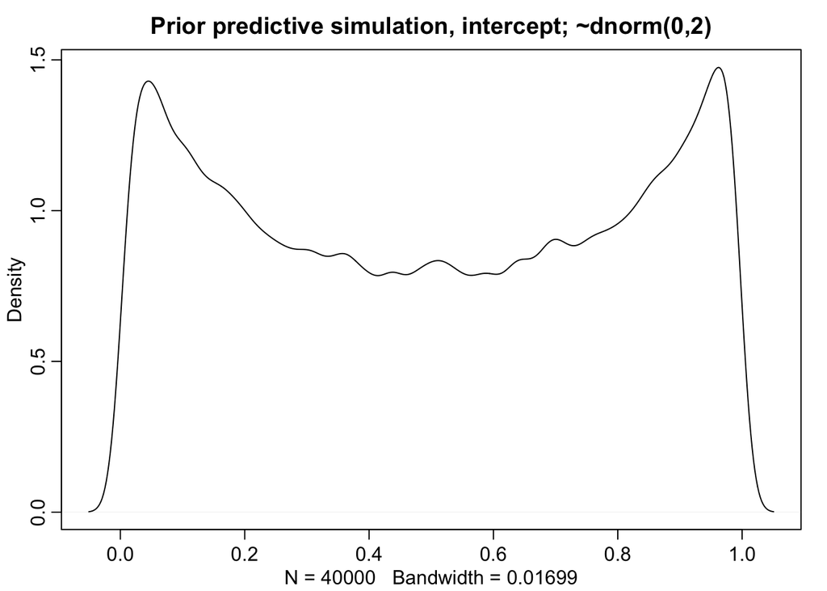

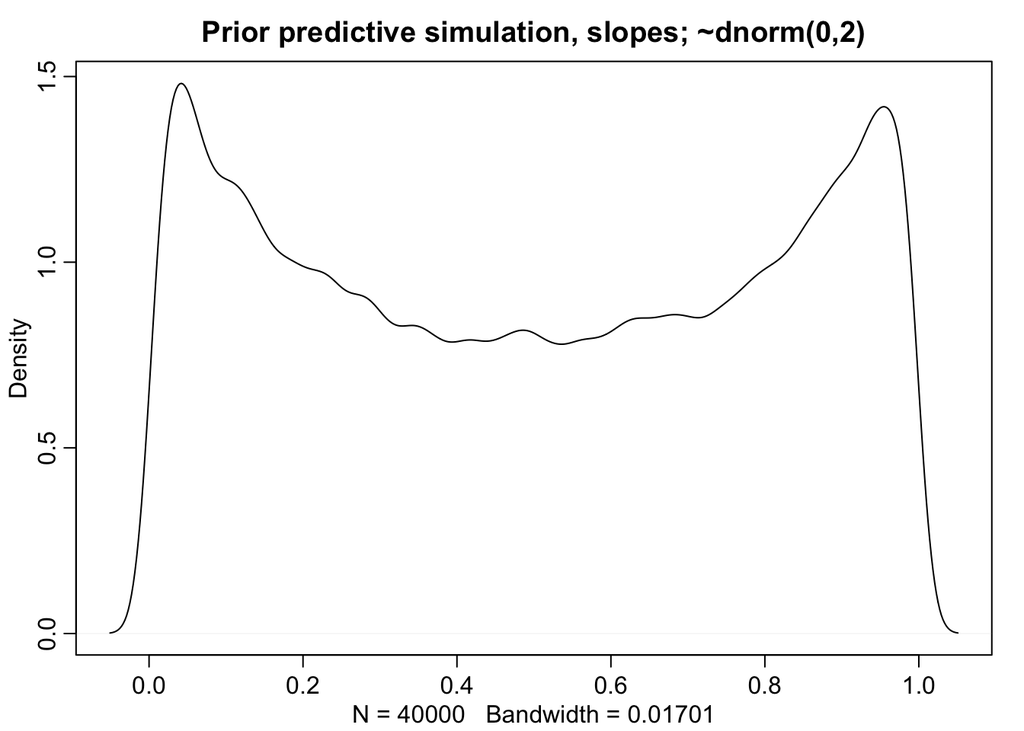

A similar exercise as above, but with smaller priors ( ~ dnorm(0, 1.5)) is presented below. The dens-plot illustrates the prior predictive simulation for the use of somewhat narrower priors (i.e. ~dnorm(0, 1.5)).

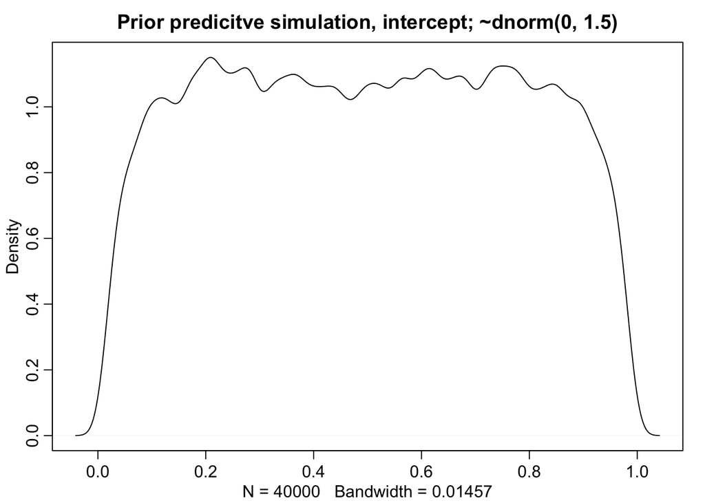

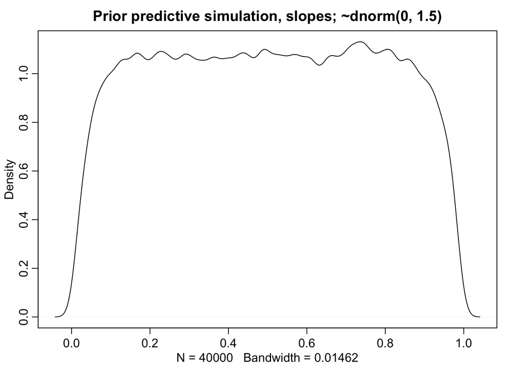

Running with these priors, what follows are point estimates for the projected likelihood of **theft** at time 1 and time 2 controlling for individual crime propensity, followed by the projected likelihood of **violence** at time 1 and time 2.

#### Main analysis, theft, time 1.

The plot below illustrates how crime propensity is associated with the projected likelihood of theft. It is clear that different scenarios entail different intercepts (X = 0 = mean of crime propensity), but that the slopes do not differ substantially: they are all positive (i.e. the higher the crime propensity, the higher the likelihood of projected theft)

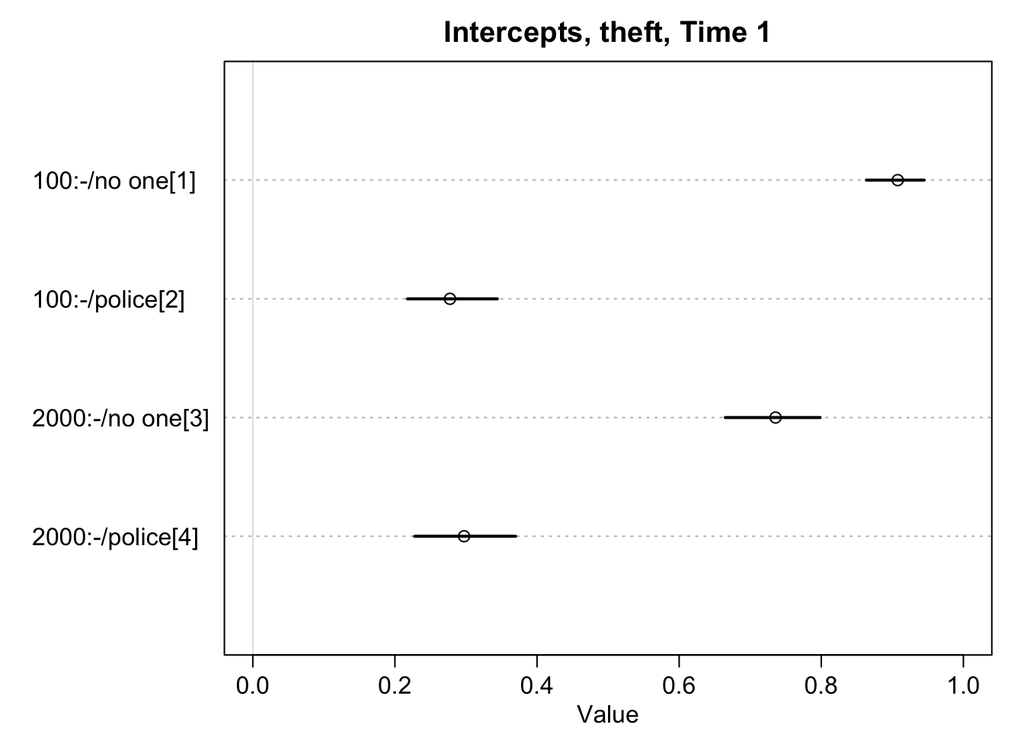

```r
set.seed(1995)
post.mst1 <- extract.samples(mst1)
a_post <- inv_logit(post.mst1$a)
b_post <- inv_logit(post.mst1$b)

plot(precis(as.data.frame(a_post)), xlim=c(0,1), labels=Bscen_stold, main ="Intercepts, theft, Time 1")
```

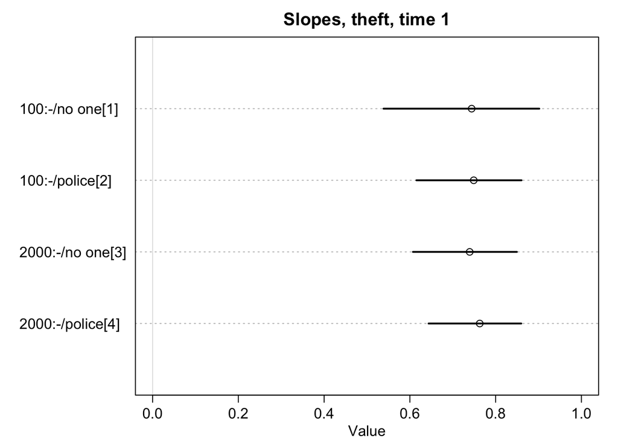

```r
plot(precis(as.data.frame(b_post)), xlim = c(0,1), labels=Bscen_stold, main = "Slopes, theft, time 1")
```

Below you find the point estimates for each scenario on a logit scale. As a reminder which scenario is which:

| What | Scenario | Motivation | Monitoring |
| --- | --- | --- | --- |
| Theft, T1 |  |  |  |
|  | 1: | 100 SEK (≈ 10 €) | None |
|  | 2: | 100 SEK | Police officer |
|  | 3: | 2000 SEK (≈ 200 €) | None |
|  | 4: | 2000 SEK | Police officer |

```
##       mean   sd  5.5% 94.5%   n_eff Rhat
## a[1]  2.32 0.31  1.84  2.84 1979.50    1
## a[2] -0.97 0.20 -1.28 -0.64 2570.19    1
## a[3]  1.03 0.22  0.69  1.38 2558.79    1
## a[4] -0.87 0.21 -1.22 -0.53 2715.22    1
## b[1]  1.16 0.63  0.15  2.22 2336.00    1
## b[2]  1.13 0.41  0.47  1.82 2530.96    1
## b[3]  1.08 0.41  0.44  1.73 2042.67    1
## b[4]  1.21 0.38  0.59  1.81 2087.38    1
```

#### Main analysis, theft, time 2.

Similar as above but instead projected theft at time 2.

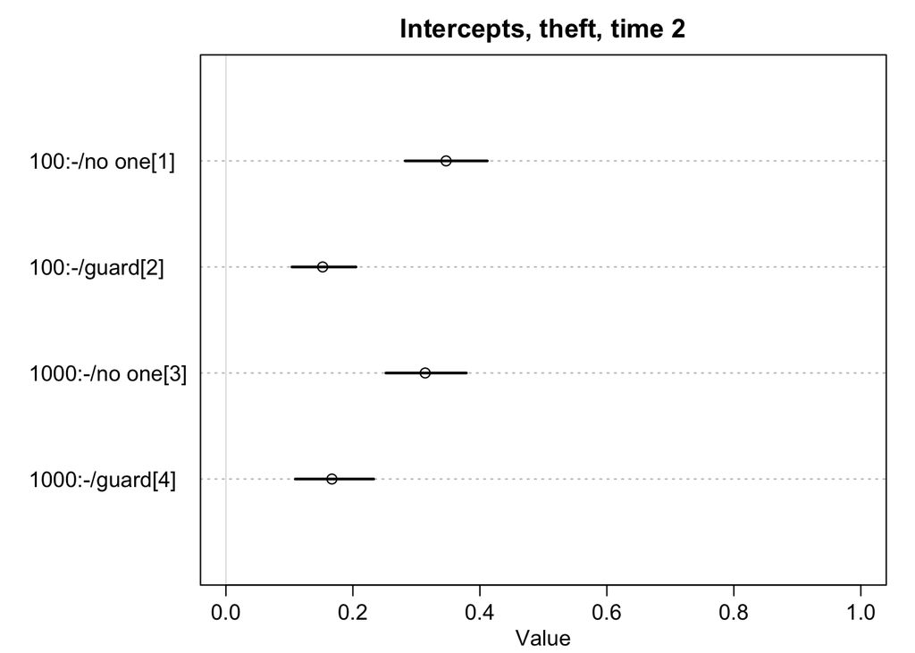

```r
set.seed(374)
post.mst2 <- extract.samples(mst2)
a_post.mst2 <- inv_logit(post.mst2$a)
b_post.mst2 <- inv_logit(post.mst2$b)
plot(precis(as.data.frame(a_post.mst2)), xlim=c(0,1), labels=Cscen_stold, main = "Intercepts, theft, time 2")
```

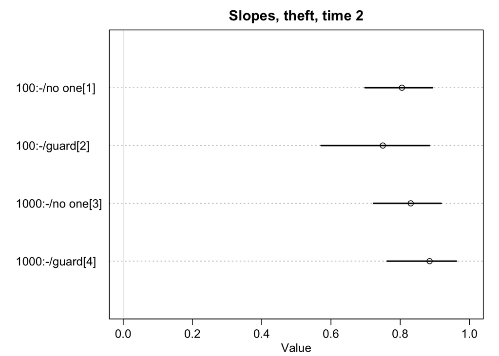

```r
plot(precis(as.data.frame(b_post.mst2)), xlim=c(0,1), labels=Cscen_stold, main = "Slopes, theft, time 2")
```

And the point estimates on a logit scale, as well as a reminder which scenario is which:

| What | Scenario | Motivation | Monitoring |
| --- | --- | --- | --- |
| : Theft, T2 |  |  |  |
|  | 1: | 100 SEK (≈ 10 €) | None |
|  | 2: | 100 SEK | Security guard |
|  | 3: | 1000 SEK (≈ 100 €) | None |
|  | 4: | 1000 SEK | Security guard |

```
##       mean   sd  5.5% 94.5%   n_eff Rhat
## a[1] -0.64 0.18 -0.93 -0.36 2473.57    1
## a[2] -1.74 0.25 -2.15 -1.36 2223.88    1
## a[3] -0.79 0.19 -1.09 -0.49 2389.78    1
## a[4] -1.63 0.29 -2.10 -1.19 2192.18    1
## b[1]  1.47 0.40  0.84  2.13 2396.20    1
## b[2]  1.17 0.55  0.29  2.04 2155.07    1
## b[3]  1.65 0.46  0.96  2.42 2234.88    1
## b[4]  2.20 0.66  1.16  3.24 1883.83    1
```

##### Comparison: theft, T1 vs T2.

The results indicate that adolescents would, in general, be more likely to keep the money under scenarios without monitoring (regardless of motivation) at both time 1 and time 2. The difference is more pronounced at T1 than T2. Scenario 1 (100:-/no one) differs reliably from scenario 3 (2000:-/no one) at T1 comparing the 89% credibility intervals (see point estimates). That is, adolescents were more likely to keep 100:- than 2000:- in the absence of monitoring. The same is not true at T2. At time 2 instead, adolescents responding to the scenarios without monitoring were more likely to keep the money than adolescents responding to scenarios with monitoring. But, level of motivation was irrelevant.

Across scenarios, more crime prone adolescents were more likely to keep the money. The tendency of a steeper slope for the most crime prone adolscents were less sensitive to deterrence (monitoring).

All in all, the results do speak in favor of the theoretical workings of the perception-choice process since level of monitoring affects “choice”-part.

#### Main analysis, violence, time 1.

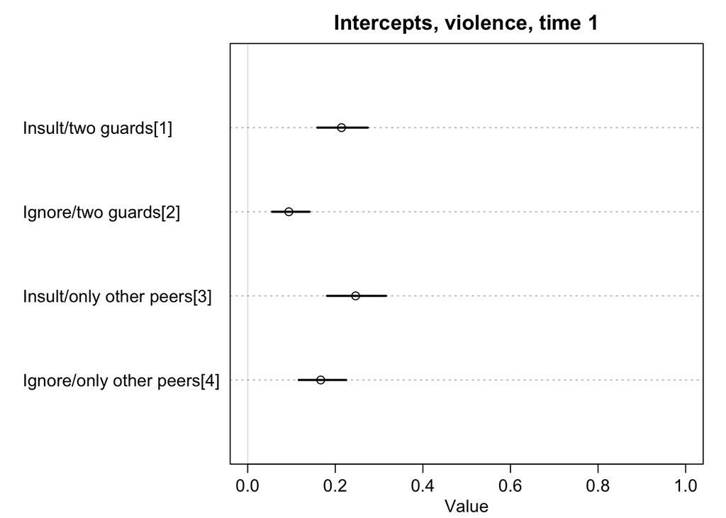

```r
post.vt1 <- extract.samples(vt1)
a_post.vt1 <- inv_logit(post.vt1$a)
b_post.vt1 <- inv_logit(post.vt1$b)
plot(precis(as.data.frame(a_post.vt1)), xlim=c(0,1), labels=Bscen_lab_v, main = "Intercepts, violence, time 1")
```

[figure not shown]

[output not shown]

```r
plot(precis(as.data.frame(b_post.vt1)), xlim = c(0,1), labels=Bscen_lab_v, main = "Slopes, violence, time 2")
```

#### Main analysis, violence, time 2.

A plot over intercepts and slopes for projected violence at time 2.

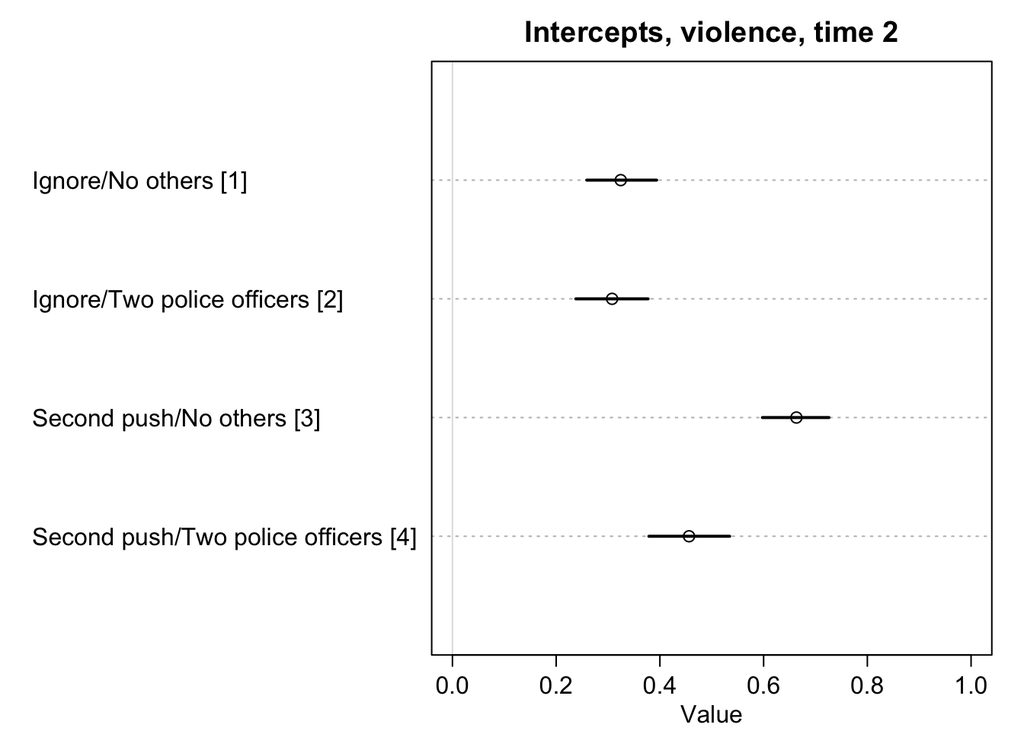

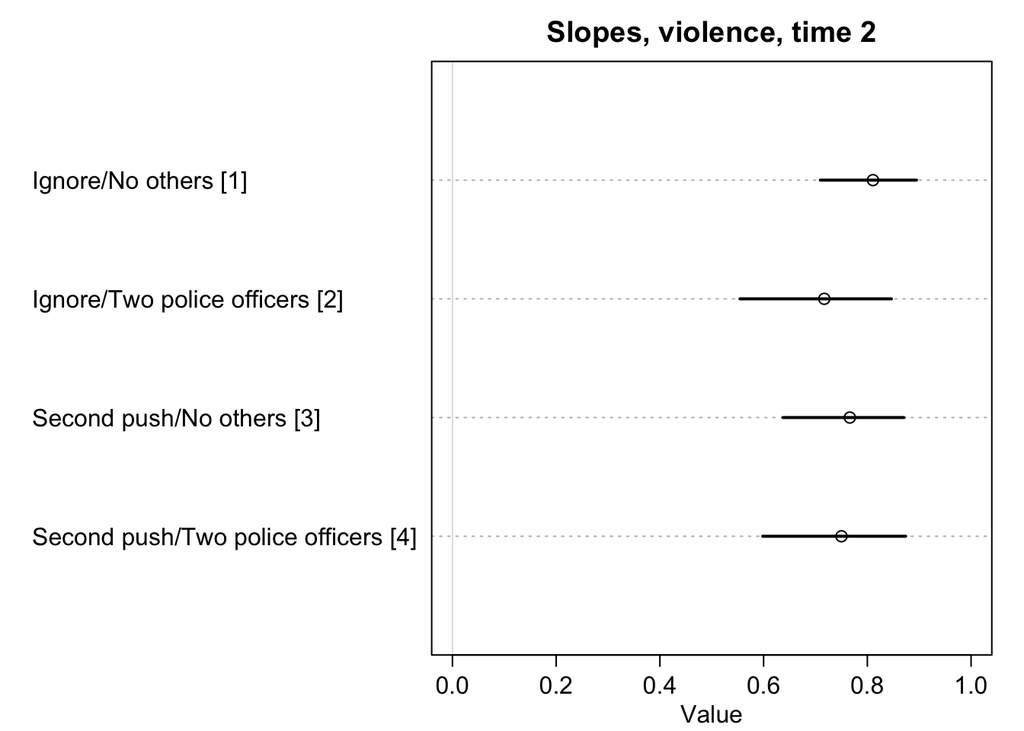

As a reminder what the different scenarios entail:

| What | Scenario | Motivation | Monitoring |
| --- | --- | --- | --- |
| : Violence, T2 |  |  |  |
|  | 1: | Pushed and ignored | None |
|  | 2: | Pushed and ignored | Police officers |
|  | 3: | Pushed twice, iPod broken | None |
|  | 4: | Pushed twice, iPod broken | Police officers |

```
##       mean   sd  5.5% 94.5%   n_eff Rhat
## a[1] -0.74 0.19 -1.05 -0.43 2913.63    1
## a[2] -0.82 0.20 -1.16 -0.50 2547.06    1
## a[3]  0.68 0.18  0.40  0.97 2591.94    1
## a[4] -0.18 0.20 -0.49  0.14 2983.36    1
## b[1]  1.50 0.39  0.89  2.14 2884.31    1
## b[2]  0.98 0.47  0.22  1.71 2698.71    1
## b[3]  1.23 0.42  0.56  1.91 3015.93    1
## b[4]  1.16 0.49  0.40  1.94 2188.11    1
```

##### Comparison: violence, T1 vs T2.

Results show that adolescents, in general, are unlikely to choose violence as a response to a provocation at time 1, but somewhat more likely at time 2. Across both time points, and across scenarios, more crime-prone adolescents are more likely to choose violence as projected act. Adolescents under scenarios involving a higher level of friction (an insult at time 1, and a second push at time 2) are more likely to report projected violence. Level of monitoring seems to have a larger effect at time 2 than at time 1.

The results speak in favour of the perception-choice process, as the perception of a violent act as a viable action alternative seems to be triggered by a higher level of friction (provocation), and subsequently affected by monitoring (influencing the choice-process).